# Temporal variability in Lake Champlain basins

Rosalie Bruel

24/01/2019

# 1 Introduction

A significant advantage to using Lake Champlain to compare food web models is that the lake is divided (by causeways) into four trophically different basins. The **Main Lake** is deep (122 m) and meso-oligotrophic, **Malletts Bay** is moderately deep (50 m) and oligotrophic, and the **Inland Sea** is moderately deep (35 m) and meso-eutrophic, whereas **Missisquoi Bay** is shallow (7 m) and highly eutrophic. Therefore, comparisons can be made among models and among different trophic systems within the same lake. For example, coldwater fish species avoid Missisquoi Bay, and stocked lake trout avoid the Inland Sea in summer, resulting in lower pressures on the forage base and different upper food webs compared to the Main Lake. Forage fish monitoring has been conducted in all of the basins except Missisquoi Bay; long-term ecological monitoring stations are present in all basins.

# 2 Materials and methods

## 2.1 Prep data

I edited the data and will work from mainly two datasets: - a data set where intra-annual variability has been preserved (each measurement is still linked to its measurement date), - a data set where I averaged the parameter per year.

```r
total[1:5,1:7]
```

|  | VisitDate | StationID | Alkalinity | Calcium | Chloride | Chlorophyll-a | Conductivity |
| --- | --- | --- | --- | --- | --- | --- | --- |
| 1 | 1992-05-07 | 7 | 54.95 | NaN | 12.30 | 11.43 | NaN |
| 2 | 1992-05-07 | 19 | 51.05 | NaN | 11.65 | 4.96 | NaN |
| 3 | 1992-05-11 | 50 | 26.90 | NaN | 6.70 | 7.64 | NaN |
| 4 | 1992-05-12 | 33 | 40.15 | NaN | 9.20 | NaN | NaN |
| 5 | 1992-05-12 | 34 | 47.50 | NaN | 9.60 | NaN | NaN |

```r
total_year[1:5,1:7]
```

|  | VisitDate | StationID | Alkalinity | Calcium | Chloride | Chlorophyll-a | Conductivity |
| --- | --- | --- | --- | --- | --- | --- | --- |
| 1 | 1992 | 2 | 87.52727 | NaN | 13.45455 | 7.724444 | 224.1250 |
| 2 | 1992 | 4 | 73.57333 | NaN | 17.39333 | 9.227000 | 214.5833 |
| 3 | 1992 | 7 | 53.96522 | NaN | 11.74167 | 5.508182 | 148.5000 |
| 4 | 1992 | 19 | 51.10385 | NaN | 11.39615 | 5.053636 | 114.5000 |
| 5 | 1992 | 21 | 52.11333 | NaN | 11.39333 | 5.698182 | 118.0000 |

## 2.2 Check outliers

Running the code below takes a lot of time, so summary of outliers given below. Uncomment the ‘dotchart()’ to see individual plots.

It seems that there might be an outlier for the Net Phytoplankton, Chlorophyta biovolume + density (one value is 4 times higher than the previous max). The outlier is for station 4 (South Lake) on 2006-09-27 - not a site I’m using so not too bad.

Outlier too for Chrysophyta biovolume, station 50 (Missisquoi Bay) on 2014-09-19.

Max value (but doesn’t behave as an outlier) for Cyanobacteria on 2013-07-30, at station 51 (Missiquoi Bay).

No outlier for Pyrrophyta biovolume either, max value on 2008-06-27, station 25 (Malletts Bay). Max values for Pyrrophyta density on 2007-07-16 for stations 34 and 40 (Northeast Arm, Inland Sea).

For Net phytoplankton, total biovolume, max value on 2014-09-19 for station 50 (Missisquoi Bay). For Net phytoplankton, total density, max value on 2013-07-30 for station 51 (Missisquoi Bay).

For Ortho-Phosphorus, max value for station 2 on 1994-07-27 (most likely an outlier).

Total Phosphorus, max value for station 2 on 2004-08-17 (235 µg/L).

Max Total Suspended solids for station 2 (South Lake, southern most station) on 2004-08-17.

```r
total[order(total$`Net phytoplankton, Chlorophyta biovolume`, decreasing = T),][1:5,1:2]
```

|  | VisitDate | StationID |
| --- | --- | --- |
| 2811 | 2006-09-27 | 4 |
| 2971 | 2007-07-30 | 34 |
| 3076 | 2007-10-18 | 4 |
| 3537 | 2009-09-02 | 4 |
| 2949 | 2007-07-16 | 40 |

```r
total[order(total$`Net phytoplankton, Chlorophyta density`, decreasing = T),][1:5,1:2]
```

|  | VisitDate | StationID |
| --- | --- | --- |
| 2811 | 2006-09-27 | 4 |
| 3076 | 2007-10-18 | 4 |
| 4503 | 2013-07-25 | 7 |
| 4769 | 2014-08-19 | 40 |
| 3984 | 2011-08-11 | 4 |

```r
total[order(total$`Net phytoplankton, Chrysophyta biovolume`, decreasing = T),][1:5,1:2]
```

|  | VisitDate | StationID |
| --- | --- | --- |
| 4813 | 2014-09-19 | 50 |
| 4500 | 2013-07-24 | 4 |
| 3984 | 2011-08-11 | 4 |
| 3736 | 2010-07-29 | 50 |
| 4316 | 2012-09-14 | 50 |

```r
total[order(total$`Net phytoplankton, Cyanobacteria biovolume`, decreasing = T),][1:5,1:2]
```

|  | VisitDate | StationID |
| --- | --- | --- |
| 4510 | 2013-07-30 | 51 |
| 4281 | 2012-08-21 | 51 |
| 2803 | 2006-09-22 | 51 |
| 3253 | 2008-08-20 | 50 |
| 3228 | 2008-08-06 | 51 |

```r
total[order(total$`Net phytoplankton, Cyanobacteria density`, decreasing = T),][1:5,1:2]
```

|  | VisitDate | StationID |
| --- | --- | --- |
| 4510 | 2013-07-30 | 51 |
| 4281 | 2012-08-21 | 51 |
| 3253 | 2008-08-20 | 50 |
| 4509 | 2013-07-30 | 50 |
| 2803 | 2006-09-22 | 51 |

```r
total[order(total$`Net phytoplankton, Pyrrophyta biovolume`, decreasing = T),][1:5,1:2]
```

|  | VisitDate | StationID |
| --- | --- | --- |
| 3161 | 2008-06-27 | 25 |
| 2948 | 2007-07-16 | 34 |
| 2949 | 2007-07-16 | 40 |
| 3460 | 2009-07-20 | 34 |
| 4002 | 2011-08-22 | 4 |

```r
total[order(total$`Net phytoplankton, Pyrrophyta density`, decreasing = T),][1:5,1:2]
```

|  | VisitDate | StationID |
| --- | --- | --- |
| 2948 | 2007-07-16 | 34 |
| 2949 | 2007-07-16 | 40 |
| 3161 | 2008-06-27 | 25 |
| 4002 | 2011-08-22 | 4 |
| 3460 | 2009-07-20 | 34 |

```r
total[order(total$`Net phytoplankton, total biovolume`, decreasing = T),][1:5,1:2]
```

|  | VisitDate | StationID |
| --- | --- | --- |
| 4813 | 2014-09-19 | 50 |
| 4281 | 2012-08-21 | 51 |
| 4500 | 2013-07-24 | 4 |
| 3984 | 2011-08-11 | 4 |
| 4316 | 2012-09-14 | 50 |

```r
total[order(total$`Net phytoplankton, total density`, decreasing = T),][1:5,1:2]
```

|  | VisitDate | StationID |
| --- | --- | --- |
| 4510 | 2013-07-30 | 51 |
| 4281 | 2012-08-21 | 51 |
| 3253 | 2008-08-20 | 50 |
| 4509 | 2013-07-30 | 50 |
| 4975 | 2015-07-20 | 51 |

```r
total[order(total$`Ortho-Phosphorus`, decreasing = T),][1:5,1:2]
```

|  | VisitDate | StationID |
| --- | --- | --- |
| 384 | 1994-07-27 | 2 |
| 38 | 1992-06-22 | 50 |
| 261 | 1993-09-03 | 50 |
| 97 | 1992-09-01 | 34 |
| 274 | 1993-09-20 | 50 |

```r
total[order(total$`Total Phosphorus`, decreasing = T),][1:5,1:2]
```

|  | VisitDate | StationID |
| --- | --- | --- |
| 2286 | 2004-08-17 | 2 |
| 3837 | 2010-10-04 | 51 |
| 5123 | 2015-10-27 | 25 |
| 384 | 1994-07-27 | 2 |
| 4801 | 2014-09-12 | 51 |

```r
total[order(total$`Total Suspended Solids`, decreasing = T),][1:5,1:2]
```

|  | VisitDate | StationID |
| --- | --- | --- |
| 2286 | 2004-08-17 | 2 |
| 2165 | 2003-10-31 | 2 |
| 1672 | 2001-06-13 | 2 |
| 1539 | 2000-08-02 | 2 |
| 384 | 1994-07-27 | 2 |

## 2.3 Write a function to do PCAs

Creating a function to repeat the PCA more easily across station.

```r
# Parameters of the function should be:
#  mstationID= the number of the monitoring site, e.g., 2= South Lake B
#  replaceNas= logical argument to indicate whether NAs should be replaced by average mean. Default to TRUE
mpca_data <- function(mstationID, replaceNAs=T)
{
  mdata <- total_year[total_year$StationID==mstationID,]

  # First, deleting the columns that have only NAs (could happen when some parameters where never measured at the specific station)
  mdata <- mdata[colSums(!is.na(mdata)) > 0]

  # NAs cannot be handled by the PCA.
  # I'm replacing the NAs by the column average, so they won't get any weight in the analysis
  if (replaceNAs) for (i in 3:ncol(mdata)) {
    mdata[is.na(mdata[,i]),i] <- mean(mdata[,i], na.rm=T)
  }

  return(mdata)
}
```

# 3 Results

## 3.1 Main Lake

The Main Lake is deep (122 m) and meso-oligotrophic. The monitoring point 19 is in the middle of the main lake.

```r
mydata <- mpca_data(mstationID = 19, replaceNAs = TRUE)

  acpR<-dudi.pca(mydata[,-c(1,2)], scannf = FALSE)
  summary(acpR)
```

```
## Class: pca dudi
## Call: dudi.pca(df = mydata[, -c(1, 2)], scannf = FALSE)
##
## Total inertia: 36
##
## Eigenvalues:
##     Ax1     Ax2     Ax3     Ax4     Ax5
##   6.881   5.233   4.900   3.306   2.861
##
## Projected inertia (%):
##     Ax1     Ax2     Ax3     Ax4     Ax5
##  19.113  14.537  13.611   9.183   7.948
##
## Cumulative projected inertia (%):
##     Ax1   Ax1:2   Ax1:3   Ax1:4   Ax1:5
##   19.11   33.65   47.26   56.44   64.39
##
## (Only 5 dimensions (out of 25) are shown)
```

```r
  s.corcircle(acpR$co, clab=0.8)
```

[figure not shown]

```r
  s.label(acpR$l1, clabel=0.6, label = mydata$VisitDate)
```

[figure not shown]

```r
#  legend("topleft", legend = c(paste("PC1:",round(acpR$eig[1]/sum(acpR$eig)*100,2),"%",sep=""), paste("PC2:",round(acpR$eig[2]/sum(acpR$eig)*100,2),"%"),sep=""), cex=.4)
  #s.arrow(acpR$co, add.p=TRUE)
```

## 3.2 Mallets Bay

Malletts Bay is moderately deep (50 m) and oligotrophic

```r
mydata <- mpca_data(mstationID = 25, replaceNAs = TRUE)

acpR<-dudi.pca(mydata[,-c(1,2)], scannf = FALSE)
summary(acpR)
```

```
## Class: pca dudi
## Call: dudi.pca(df = mydata[, -c(1, 2)], scannf = FALSE)
##
## Total inertia: 36
##
## Eigenvalues:
##     Ax1     Ax2     Ax3     Ax4     Ax5
##   6.114   5.547   3.856   3.577   2.969
##
## Projected inertia (%):
##     Ax1     Ax2     Ax3     Ax4     Ax5
##  16.982  15.409  10.710   9.937   8.249
##
## Cumulative projected inertia (%):
##     Ax1   Ax1:2   Ax1:3   Ax1:4   Ax1:5
##   16.98   32.39   43.10   53.04   61.29
##
## (Only 5 dimensions (out of 25) are shown)
```

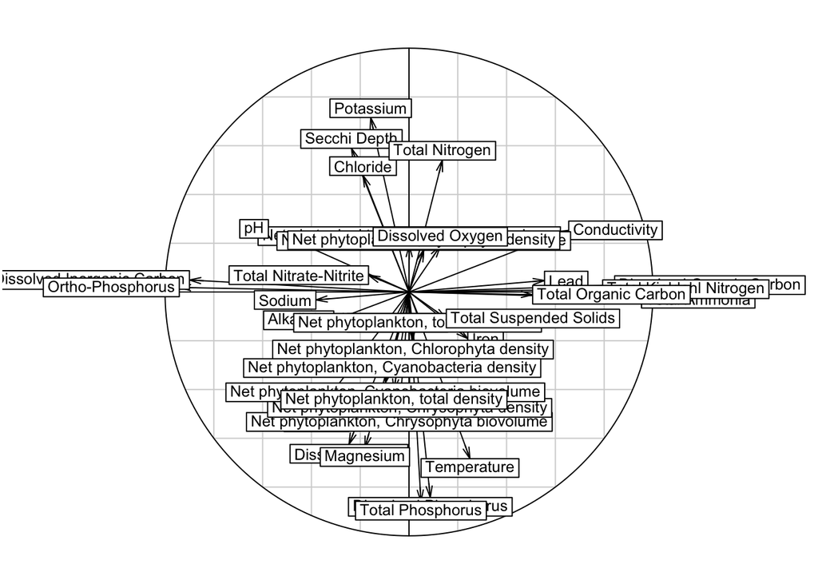

```r
s.corcircle(acpR$co, clab=0.8)
```

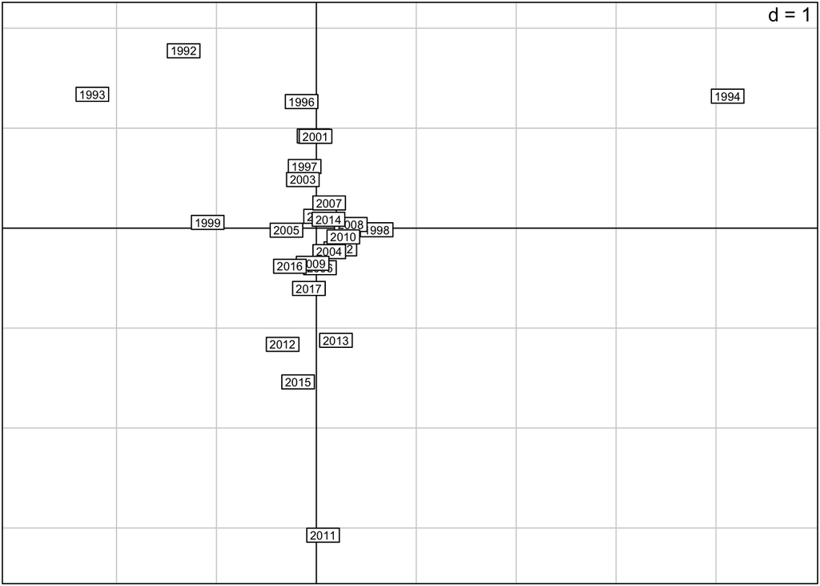

```r
s.label(acpR$l1, clabel=0.6, label = mydata$VisitDate)
```

## 3.3 Inland Sea

The Inland Sea is moderately deep (35 m) and meso-eutrophice.

```r
mydata <- mpca_data(mstationID = 34, replaceNAs = TRUE)

acpR<-dudi.pca(mydata[,-c(1,2)], scannf = FALSE)
summary(acpR)
```

```
## Class: pca dudi
## Call: dudi.pca(df = mydata[, -c(1, 2)], scannf = FALSE)
##
## Total inertia: 36
##
## Eigenvalues:
##     Ax1     Ax2     Ax3     Ax4     Ax5
##   7.234   5.069   4.377   3.030   2.554
##
## Projected inertia (%):
##     Ax1     Ax2     Ax3     Ax4     Ax5
##  20.094  14.080  12.158   8.418   7.093
##
## Cumulative projected inertia (%):
##     Ax1   Ax1:2   Ax1:3   Ax1:4   Ax1:5
##   20.09   34.17   46.33   54.75   61.84
##
## (Only 5 dimensions (out of 25) are shown)
```

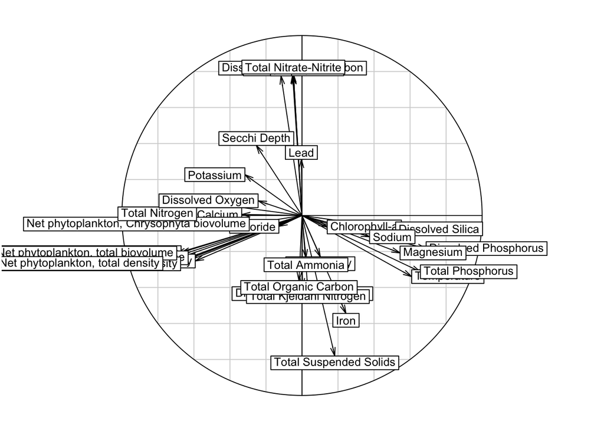

```r
s.corcircle(acpR$co, clab=0.8)
```

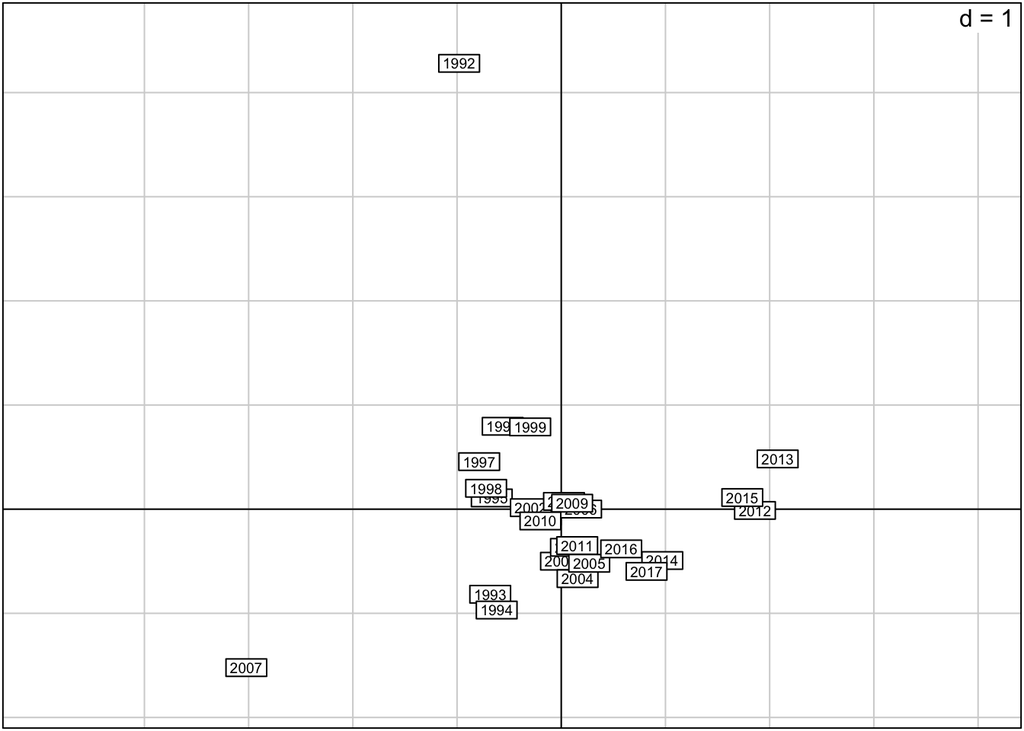

```r
s.label(acpR$l1, clabel=0.6, label = mydata$VisitDate)
```

# 4 Mapping

## 4.1 Visualize the monitoring stations

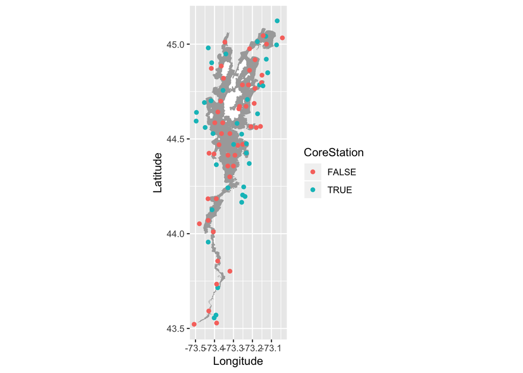

## 4.2 Plot some parameters and see the average per sites

This is an interactive tool if you go back to the script. Here, the visualization is for the following parameters:

```r
parameter <- "Total Phosphorus"

min_yr    <- 1990
max_yr    <- 2018
mysubset <- total[which(as.numeric(substring(total$VisitDate, 1, 4))>=min_yr & as.numeric(substring(total$VisitDate, 1, 4))<=max_yr),]
```

Some parameters were not measured for the whole period. **5593** are available for the above parameters.

Parameters to chose from are:  
-Alkalinity  
-Calcium  
-Chloride  
-Chlorophyll-a  
-Conductivity  
-Dissolved Inorganic Carbon  
-Dissolved Organic Carbon  
-Dissolved Phosphorus  
-Dissolved Silica  
-Iron  
-Lead  
-Magnesium  
-Net phytoplankton, Chlorophyta biovolume  
-Net phytoplankton, Chlorophyta density  
-Net phytoplankton, Chrysophyta biovolume  
-Net phytoplankton, Chrysophyta density  
-Net phytoplankton, Cyanobacteria biovolume  
-Net phytoplankton, Cyanobacteria density  
-Net phytoplankton, Pyrrophyta biovolume  
-Net phytoplankton, Pyrrophyta density  
-Net phytoplankton, total biovolume  
-Net phytoplankton, total density  
-Ortho-Phosphorus  
-pH  
-Potassium  
-Secchi Depth  
-Sodium  
-Temperature  
-Total Ammonia  
-Total Kjeldahl Nitrogen  
-Total Nitrate-Nitrite  
-Total Nitrogen  
-Total Organic Carbon  
-Total Phosphorus  
-Total Suspended Solids  
-Dissolved Oxygen

Plot that on the map.

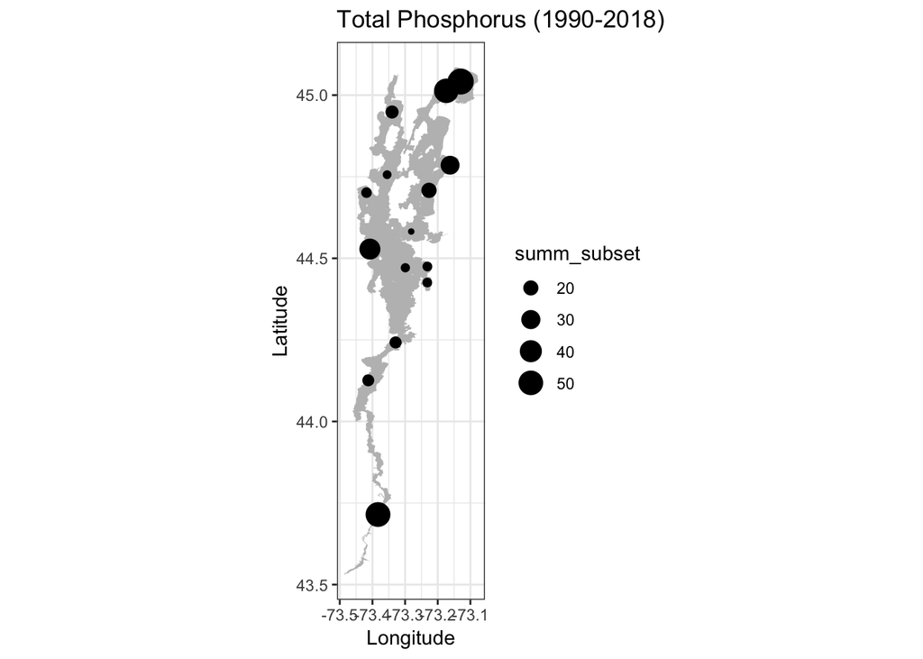